# Peer Assesment 1

## Loading and preprocessing the data

Download the data

[Download the dataset](https://d396qusza40orc.cloudfront.net/repdata%2Fdata%2Factivity.zip)

Load the data

```r
data <- read.csv("activity.csv")
```

## What is mean total number of steps taken per day?

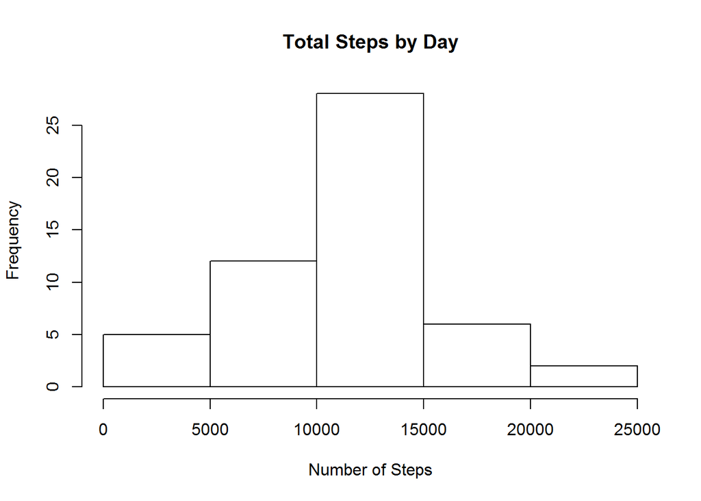

```r
steps_day <- aggregate(steps ~ date, data, sum)
hist(steps_day$steps, main = "Total Steps by Day", xlab="Number of Steps")
```

```r
stepmean <- mean(steps_day$steps)
stepmedian <- median(steps_day$steps)
```

## What is the average daily activity pattern?

1. Make a timeseries plot of the 5-minute interval (x-axis) and the average number of steps taken, averaged across all days (yaxis)
2. Which 5-minute interval, on average across all the days in the dataset, contains the maximum number of steps?

Calculate average steps for each interval, plot, and find interval with highest average:

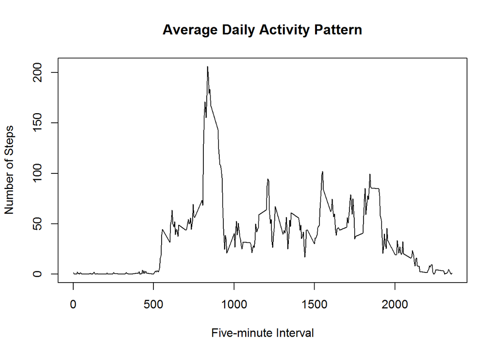

```r
steps_interval <- aggregate(steps ~ interval, data, mean)

plot(steps_interval$interval,steps_interval$steps, type="l", xlab="Five-minute Interval", ylab="Number of Steps",main="Average Daily Activity Pattern")
```

```r
max_interval <- steps_interval[which.max(steps_interval$steps),1]
```

The 5-minute interval, on average across all the days in the dataset, with the maximum number of steps is 835

## Impute missing values

1. Calculate and report the total number of missing values in the dataset (i.e. the total number of rows with NAs)

```r
missing <- sum(!complete.cases(data))
```

The total number of missing values in the dataset is 2304

Change “NAs” to the mean value of that five-minute interval and create a new dataset (alldata) that is equal to the original dataset but with the missing data filled in.:

```r
alldata <- data
nas <- is.na(alldata$steps)
mean_interval <- tapply(alldata$steps, alldata$interval, mean, na.rm=TRUE, simplify=TRUE)
alldata$steps[nas] <- mean_interval[as.character(alldata$interval[nas])]
```

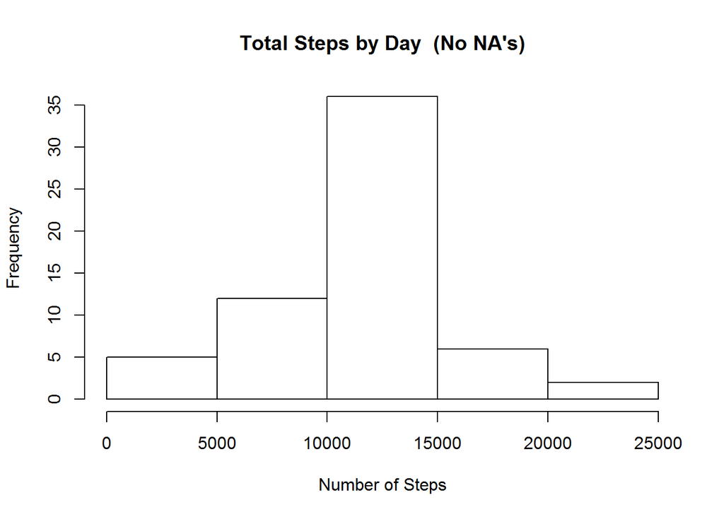

```r
allsteps_day <- aggregate(steps ~ date, alldata, sum)
hist(allsteps_day$steps, main = "Total Steps by Day  (No NA's)", xlab="Number of Steps")
```

```r
allstepmean <- mean(steps_day$steps)
allstepmedian <- median(steps_day$steps)

meandiff <- (stepmean - allstepmean)
mediandiff <- (stepmedian - allstepmean)
```

## Are there differences in activity patterns between weekdays and weekends?

1. Create a new factor variable in the dataset with too level - “weekday” and “weekend”

```r
weekdays <- c("Monday", "Tuesday", "Wednesday", "Thursday","Friday")

alldata$dow = as.factor(ifelse(is.element(weekdays(as.Date(alldata$date)),weekdays), "Weekday", "Weekend"))

steps_alldata <- aggregate(steps ~ interval + dow, alldata, mean)
```

2. Make a planel plot containing a time serios plot of the 5-minute interval (x-axis) and the average number of steps taken, averaged across all weekday days or weekend days (y-axis)

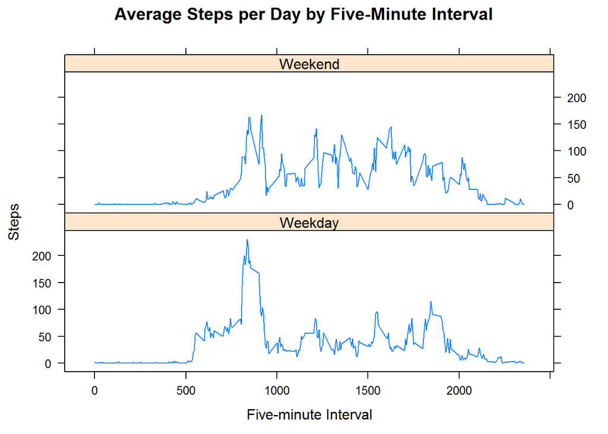

```r
library(lattice)

xyplot(steps_alldata$steps ~ steps_alldata$interval|steps_alldata$dow, main="Average Steps per Day by Five-Minute Interval",xlab="Five-minute Interval", ylab="Steps",layout=c(1,2), type="l")
```